# RETRASCORE - Heatmap de lesiones graves por región anatómica AIS

Cruce de las 9 regiones AIS y mortalidad a 30 días

2026-11-24

# 1 Objetivo

# 2 Parámetros

```r
input_file <- "retrauci_regiones_ais_completas.csv"
output_dir <- "outputs_heatmap_lesiones_ais"

year_range <- c(2015L, 2025L)   # año del trauma
minimum_age <- 18               # se eliminan los menores de 18 años
severe_threshold <- 4           # lesión grave: AIS máximo de la región >= 3
number_of_lesions <- 32L

region_names <- c(
  "Craneo", "Cara", "Cuello", "Torax", "Abdomen",
  "Columna vertebral", "Extremidades superiores",
  "Extremidades inferiores", "Piel y partes blandas"
)

# English labels used only inside the heatmap figure
region_names_en <- c(
  "Head", "Face", "Neck", "Thorax", "Abdomen",
  "Spine", "Upper extremities", "Lower extremities", "Skin / soft tissue"
)

dir.create(output_dir, showWarnings = FALSE)
```

# 3 Lectura y preparación de datos

```r
if (!file.exists(input_file)) {
  stop("No se encuentra ", input_file, " en la carpeta del documento.")
}

# Todo se lee como texto para no alterar identificadores ni códigos.
raw_data <- read.csv2(
  input_file,
  stringsAsFactors = FALSE,
  colClasses = "character",
  na.strings = NULL
)

clean_text <- function(x) {
  x <- tolower(trimws(as.character(x)))
  x[x %in% c("", "na", "nas")] <- NA_character_
  x
}

clean_number <- function(x) {
  x <- trimws(as.character(x))
  x[x %in% c("", "NA", "NAS")] <- NA_character_
  suppressWarnings(as.numeric(gsub(",", ".", x)))
}

parse_dates <- function(x) {
  x <- trimws(as.character(x))
  x[x %in% c("", "NA", "NAS")] <- NA_character_
  suppressWarnings(
    parse_date_time(x, orders = c("dmy", "ymd", "dmy HMS", "ymd HMS"))
  )
}

trauma_date <- parse_dates(raw_data$fecha_trauma)
icu_discharge_date <- parse_dates(raw_data$fecha_alta_uci)
hospital_discharge_date <- parse_dates(raw_data$fecha_alta_hospital)
death_recorded_date <- parse_dates(raw_data$fecha_exitus)
```

## 3.1 Mortalidad a 30 días

La definición es la del documento `ultimate_validation_preprocessing.Rmd`: la mortalidad intrahospitalaria combina `evolucion_uci` y `evolucion_hospitalaria`, y la mortalidad a 30 días vale 1 si el paciente fallece en los 30 días siguientes al trauma y 0 si sobrevive al alta hospitalaria o fallece después del día 30. Los fallecidos sin fecha válida quedan con desenlace desconocido y se excluyen.

```r
death_labels <- c("exitus", "exitus y donacion")
icu_outcome <- clean_text(raw_data$evolucion_uci)
hospital_outcome <- clean_text(raw_data$evolucion_hospitalaria)

in_hospital_mortality <- case_when(
  icu_outcome %in% death_labels ~ 1L,
  hospital_outcome %in% death_labels ~ 1L,
  hospital_outcome == "alta" ~ 0L,
  TRUE ~ NA_integer_
)

icu_death <- icu_outcome %in% death_labels
hospital_death <- hospital_outcome %in% death_labels

death_date <- as.POSIXct(
  rep(NA_real_, nrow(raw_data)),
  origin = "1970-01-01", tz = "UTC"
)
death_date[icu_death] <- icu_discharge_date[icu_death]
death_date[hospital_death] <- hospital_discharge_date[hospital_death]

use_recorded_date <- in_hospital_mortality == 1 & is.na(death_date) &
  !is.na(death_recorded_date)
use_recorded_date[is.na(use_recorded_date)] <- FALSE
death_date[use_recorded_date] <- death_recorded_date[use_recorded_date]

days_to_death <- as.numeric(
  difftime(death_date, trauma_date, units = "days")
)
valid_death_date <- !is.na(days_to_death) & days_to_death >= 0

mortality_30d <- case_when(
  in_hospital_mortality == 0 ~ 0L,
  in_hospital_mortality == 1 & valid_death_date & days_to_death <= 30 ~ 1L,
  in_hospital_mortality == 1 & valid_death_date & days_to_death > 30 ~ 0L,
  TRUE ~ NA_integer_
)
```

## 3.2 Selección de pacientes

```r
trauma_year <- year(trauma_date)
age <- clean_number(raw_data$edad)

in_period <- !is.na(trauma_year) &
  trauma_year >= year_range[1] & trauma_year <= year_range[2]
is_minor <- !is.na(age) & age < minimum_age
known_outcome <- !is.na(mortality_30d)

keep <- in_period & !is_minor & known_outcome

selection_flow <- data.frame(
  Paso = c(
    "Registros iniciales",
    paste0("Año del trauma ", year_range[1], "-", year_range[2]),
    paste0("Menores de ", minimum_age, " años eliminados"),
    "Mortalidad a 30 días desconocida (eliminados)",
    "Pacientes analizados"
  ),
  n = c(
    nrow(raw_data),
    sum(in_period),
    sum(in_period & is_minor),
    sum(in_period & !is_minor & !known_outcome),
    sum(keep)
  )
)
knitr::kable(selection_flow, align = c("l", "r"))
```

| Paso | n |
| --- | --- |
| Registros iniciales | 19035 |
| Año del trauma 2015-2025 | 19024 |
| Menores de 18 años eliminados | 409 |
| Mortalidad a 30 días desconocida (eliminados) | 1095 |
| Pacientes analizados | 17520 |

```r
cohort <- raw_data[keep, , drop = FALSE]
died <- mortality_30d[keep]
```

# 4 Lesión grave por región AIS

Para cada paciente y región se toma el AIS máximo entre sus lesiones de esa región. La región se considera con lesión grave si ese máximo es mayor o igual que `severe_threshold`. Los pacientes sin ninguna lesión grave no aparecen en ninguna celda del heatmap. Las lesiones sin región (1-9) o sin gravedad (1-6) válida no se pueden asignar y se ignoran.

```r
lesion_region <- sapply(
  cohort[paste0("lesion_", 0:(number_of_lesions - 1L), "_region_ais")],
  clean_number
)
lesion_severity <- sapply(
  cohort[paste0("lesion_", 0:(number_of_lesions - 1L), "_gravedad")],
  clean_number
)
lesion_region[!(lesion_region %in% 1:9)] <- NA_real_
lesion_severity[!(lesion_severity %in% 1:6)] <- NA_real_

max_ais_by_region <- sapply(1:9, function(region_code) {
  severity <- ifelse(lesion_region == region_code, lesion_severity, NA_real_)
  result <- suppressWarnings(apply(severity, 1, max, na.rm = TRUE))
  result[is.infinite(result)] <- 0
  result
})
colnames(max_ais_by_region) <- region_names

severe_matrix <- (max_ais_by_region >= severe_threshold) * 1L

lesions_without_valid_data <- sum(
  !is.na(lesion_region) & is.na(lesion_severity)
)

injury_summary <- data.frame(
  Region = region_names,
  `Pacientes con lesion grave` = colSums(severe_matrix),
  `% de pacientes` = round(100 * colSums(severe_matrix) / nrow(cohort), 1),
  check.names = FALSE
)
knitr::kable(injury_summary, align = c("l", "r", "r"))
```

|  | Region | Pacientes con lesion grave | % de pacientes |
| --- | --- | --- | --- |
| Craneo | Craneo | 4359 | 24.9 |
| Cara | Cara | 55 | 0.3 |
| Cuello | Cuello | 38 | 0.2 |
| Torax | Torax | 2440 | 13.9 |
| Abdomen | Abdomen | 976 | 5.6 |
| Columna vertebral | Columna vertebral | 653 | 3.7 |
| Extremidades superiores | Extremidades superiores | 37 | 0.2 |
| Extremidades inferiores | Extremidades inferiores | 1216 | 6.9 |
| Piel y partes blandas | Piel y partes blandas | 66 | 0.4 |

```r
cat(
  "\nPacientes sin ninguna lesión grave (AIS >= ", severe_threshold, "): ",
  sum(rowSums(severe_matrix) == 0L), " (",
  round(100 * mean(rowSums(severe_matrix) == 0L), 1), "%)\n",
  "Lesiones con región pero sin gravedad válida (ignoradas): ",
  lesions_without_valid_data, "\n", sep = ""
)
```

```
##
## Pacientes sin ninguna lesión grave (AIS >= 4): 8964 (51.2%)
## Lesiones con región pero sin gravedad válida (ignoradas): 1
```

# 5 Cruce de regiones y mortalidad

```r
# n[i, j]: pacientes con lesión grave en la región i y en la región j.
# La diagonal es el total de pacientes con lesión grave en esa región.
n_matrix <- crossprod(severe_matrix)
death_matrix <- crossprod(severe_matrix, severe_matrix * died)

# Pacientes con lesión grave únicamente en una región.
# "Solo" = lesión grave en la región y AIS 0 (ninguna lesión, ni leve) en las
# otras 8 regiones. Es la misma definición de "Only this region" de
# cutoff/cutoff_justification.Rmd.
any_injury_matrix <- max_ais_by_region > 0
only_matrix <- severe_matrix * (rowSums(any_injury_matrix) == 1L)
n_only <- colSums(only_matrix)
death_only <- colSums(only_matrix * died)

pct <- function(deaths, n) ifelse(n > 0, 100 * deaths / n, NA_real_)

heat_data <- expand.grid(row_idx = 1:9, col_idx = 1:9)
heat_data$n <- n_matrix[cbind(heat_data$row_idx, heat_data$col_idx)]
heat_data$deaths <- death_matrix[cbind(heat_data$row_idx, heat_data$col_idx)]
heat_data$x <- heat_data$col_idx

only_data <- data.frame(
  row_idx = 1:9, col_idx = 10L, n = n_only, deaths = death_only, x = 10.6
)

heat_data <- rbind(heat_data, only_data)
heat_data$mortality <- pct(heat_data$deaths, heat_data$n)
heat_data$y <- 10 - heat_data$row_idx
heat_data$label <- ifelse(
  heat_data$n == 0,
  "0",
  sprintf("%d\n%.1f%%", heat_data$n, heat_data$mortality)
)

# El color depende de n. Con la escala de raíz cuadrada se distinguen mejor
# las celdas pequeñas frente a las diagonales, que son mucho mayores.
max_n <- max(heat_data$n)
heat_data$text_colour <- ifelse(
  sqrt(heat_data$n) > 0.55 * sqrt(max_n), "white", "black"
)
```

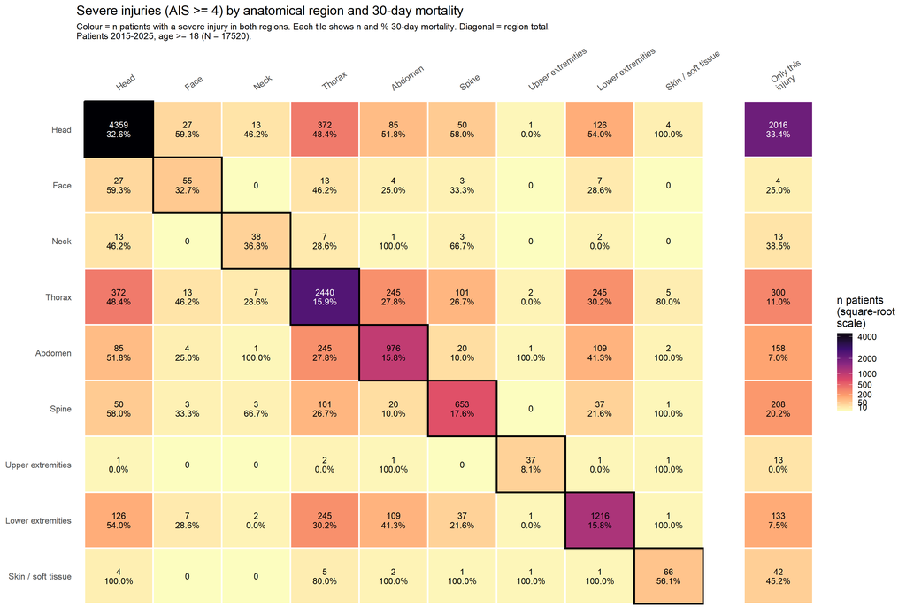

```r
diagonal_data <- heat_data[
  heat_data$col_idx == heat_data$row_idx & heat_data$x <= 9,
]

heatmap_plot <- ggplot(heat_data, aes(x = x, y = y)) +
  geom_tile(
    aes(fill = n),
    colour = "white", linewidth = 0.8, width = 1, height = 1
  ) +
  geom_tile(
    data = diagonal_data, fill = NA, colour = "black", linewidth = 1,
    width = 1, height = 1
  ) +
  geom_text(
    aes(label = label, colour = text_colour),
    size = 3.4, lineheight = 0.9
  ) +
  scale_colour_identity() +
  scale_fill_viridis_c(
    option = "magma", direction = -1, trans = "sqrt",
    breaks = c(10, 50, 200, 500, 1000, 2000, 4000, 7000),
    name = "n patients\n(square-root\nscale)"
  ) +
  scale_x_continuous(
    breaks = c(1:9, 10.6),
    labels = c(region_names_en, "Only this\ninjury"),
    position = "top", expand = c(0.01, 0.01)
  ) +
  scale_y_continuous(
    breaks = 9:1, labels = region_names_en, expand = c(0.01, 0.01)
  ) +
  labs(
    title = paste0(
      "Severe injuries (AIS >= ", severe_threshold,
      ") by anatomical region and 30-day mortality"
    ),
    subtitle = paste0(
      "Colour = n patients with a severe injury in both regions. Each tile ",
      "shows n and % 30-day mortality. Diagonal = region total.\n",
      "Patients ", year_range[1], "-", year_range[2],
      ", age >= ", minimum_age, " (N = ", nrow(cohort), ")."
    ),
    x = NULL, y = NULL
  ) +
  theme_minimal(base_size = 12) +
  theme(
    panel.grid = element_blank(),
    axis.text.x.top = element_text(angle = 35, hjust = 0, vjust = 0),
    plot.subtitle = element_text(size = 10)
  )

ggsave(
  file.path(output_dir, "heatmap_lesiones_ais.png"),
  heatmap_plot, width = 14, height = 9.5, dpi = 300
)
heatmap_plot
```

# 6 Heatmap con las 6 regiones agrupadas

Mismo heatmap que el anterior, pero con las **6 regiones agrupadas** del registro (`mais1` = cabeza, `mais2` = extremidad superior, `mais3` = tórax, `mais4` = abdomen, `mais5` = extremidad inferior incluida la pelvis y `mais6` = externa/térmica). Se usa la misma cohorte y la misma definición de lesión grave (AIS máximo de la región >= `severe_threshold`). Una celda vacía, `NA` o `NAS` en `mais1`-`mais6` se interpreta como ausencia de lesión (AIS 0), igual que en `ultimate_validation_preprocessing.Rmd`. La columna **“Only this injury”** cuenta a los pacientes con lesión grave en esa región y AIS 0 en las otras 5.

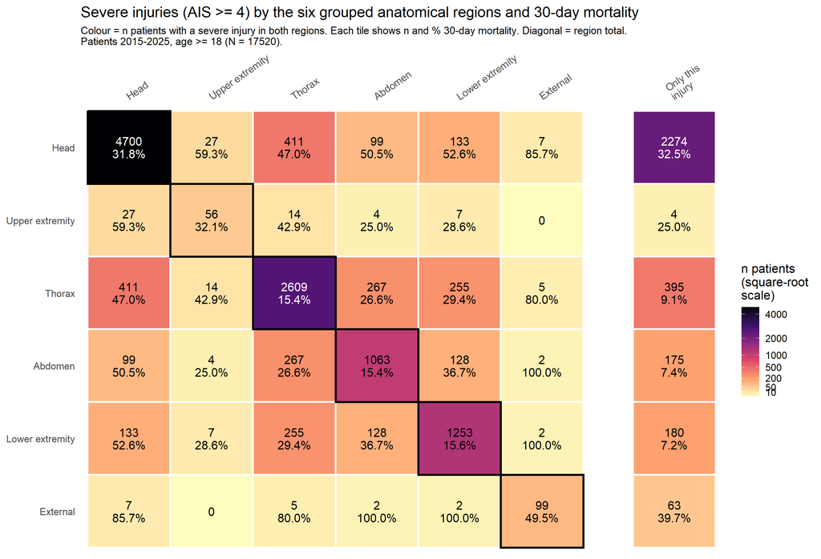

```r
region_names_6_en <- c(
  "Head", "Upper extremity", "Thorax", "Abdomen",
  "Lower extremity", "External"
)
n_groups <- length(region_names_6_en)

mais_6 <- sapply(paste0("mais", 1:n_groups), function(variable) {
  value <- clean_number(cohort[[variable]])
  value[is.na(value)] <- 0          # empty / NA / NAS = no injury
  value[!(value %in% 0:6)] <- NA_real_
  value
})
colnames(mais_6) <- region_names_6_en

severe_6 <- (mais_6 >= severe_threshold) * 1L
severe_6[is.na(severe_6)] <- 0L

n_matrix_6 <- crossprod(severe_6)
death_matrix_6 <- crossprod(severe_6, severe_6 * died)

any_injury_6 <- !is.na(mais_6) & mais_6 > 0
only_matrix_6 <- severe_6 * (rowSums(any_injury_6) == 1L)
n_only_6 <- colSums(only_matrix_6)
death_only_6 <- colSums(only_matrix_6 * died)

heat_data_6 <- expand.grid(row_idx = 1:n_groups, col_idx = 1:n_groups)
heat_data_6$n <- n_matrix_6[cbind(heat_data_6$row_idx, heat_data_6$col_idx)]
heat_data_6$deaths <- death_matrix_6[
  cbind(heat_data_6$row_idx, heat_data_6$col_idx)
]
heat_data_6$x <- heat_data_6$col_idx

only_x_6 <- n_groups + 1.6
only_data_6 <- data.frame(
  row_idx = 1:n_groups, col_idx = n_groups + 1L,
  n = n_only_6, deaths = death_only_6, x = only_x_6
)

heat_data_6 <- rbind(heat_data_6, only_data_6)
heat_data_6$mortality <- pct(heat_data_6$deaths, heat_data_6$n)
heat_data_6$y <- (n_groups + 1) - heat_data_6$row_idx
heat_data_6$label <- ifelse(
  heat_data_6$n == 0,
  "0",
  sprintf("%d\n%.1f%%", heat_data_6$n, heat_data_6$mortality)
)
heat_data_6$text_colour <- ifelse(
  sqrt(heat_data_6$n) > 0.55 * sqrt(max(heat_data_6$n)), "white", "black"
)

diagonal_data_6 <- heat_data_6[
  heat_data_6$col_idx == heat_data_6$row_idx & heat_data_6$x <= n_groups,
]

heatmap_plot_6 <- ggplot(heat_data_6, aes(x = x, y = y)) +
  geom_tile(
    aes(fill = n),
    colour = "white", linewidth = 0.8, width = 1, height = 1
  ) +
  geom_tile(
    data = diagonal_data_6, fill = NA, colour = "black", linewidth = 1,
    width = 1, height = 1
  ) +
  geom_text(
    aes(label = label, colour = text_colour),
    size = 4, lineheight = 0.9
  ) +
  scale_colour_identity() +
  scale_fill_viridis_c(
    option = "magma", direction = -1, trans = "sqrt",
    breaks = c(10, 50, 200, 500, 1000, 2000, 4000, 7000),
    name = "n patients\n(square-root\nscale)"
  ) +
  scale_x_continuous(
    breaks = c(1:n_groups, only_x_6),
    labels = c(region_names_6_en, "Only this\ninjury"),
    position = "top", expand = c(0.01, 0.01)
  ) +
  scale_y_continuous(
    breaks = n_groups:1, labels = region_names_6_en,
    expand = c(0.01, 0.01)
  ) +
  labs(
    title = paste0(
      "Severe injuries (AIS >= ", severe_threshold,
      ") by the six grouped anatomical regions and 30-day mortality"
    ),
    subtitle = paste0(
      "Colour = n patients with a severe injury in both regions. Each tile ",
      "shows n and % 30-day mortality. Diagonal = region total.\n",
      "Patients ", year_range[1], "-", year_range[2],
      ", age >= ", minimum_age, " (N = ", nrow(cohort), ")."
    ),
    x = NULL, y = NULL
  ) +
  theme_minimal(base_size = 12) +
  theme(
    panel.grid = element_blank(),
    axis.text.x.top = element_text(angle = 35, hjust = 0, vjust = 0),
    plot.subtitle = element_text(size = 10)
  )

ggsave(
  file.path(output_dir, "heatmap_lesiones_6_regiones.png"),
  heatmap_plot_6, width = 11, height = 7.5, dpi = 300
)
heatmap_plot_6
```

# 7 Tablas

## 7.1 Lesión grave en una sola región (“Solo esta lesión”)

```r
only_table <- data.frame(
  Region = region_names,
  `n total region` = as.integer(diag(n_matrix)),
  `n solo esta lesion` = as.integer(n_only),
  `% sobre el total de la region` = round(100 * n_only / diag(n_matrix), 1),
  `Fallecidos (30 d)` = as.integer(death_only),
  `Mortalidad (%)` = round(pct(death_only, n_only), 1),
  check.names = FALSE
)
knitr::kable(
  only_table, align = c("l", rep("r", 5)),
  caption = "Pacientes con lesión grave únicamente en la región indicada"
)
```

Pacientes con lesión grave únicamente en la región indicada

|  | Region | n total region | n solo esta lesion | % sobre el total de la region | Fallecidos (30 d) | Mortalidad (%) |
| --- | --- | --- | --- | --- | --- | --- |
| Craneo | Craneo | 4359 | 2016 | 46.2 | 673 | 33.4 |
| Cara | Cara | 55 | 4 | 7.3 | 1 | 25.0 |
| Cuello | Cuello | 38 | 13 | 34.2 | 5 | 38.5 |
| Torax | Torax | 2440 | 300 | 12.3 | 33 | 11.0 |
| Abdomen | Abdomen | 976 | 158 | 16.2 | 11 | 7.0 |
| Columna vertebral | Columna vertebral | 653 | 208 | 31.9 | 42 | 20.2 |
| Extremidades superiores | Extremidades superiores | 37 | 13 | 35.1 | 0 | 0.0 |
| Extremidades inferiores | Extremidades inferiores | 1216 | 133 | 10.9 | 10 | 7.5 |
| Piel y partes blandas | Piel y partes blandas | 66 | 42 | 63.6 | 19 | 45.2 |

## 7.2 Combinaciones de dos regiones

```r
pair_table <- do.call(rbind, lapply(1:8, function(i) {
  do.call(rbind, lapply((i + 1):9, function(j) {
    data.frame(
      `Region A` = region_names[i],
      `Region B` = region_names[j],
      n = as.integer(n_matrix[i, j]),
      `Fallecidos (30 d)` = as.integer(death_matrix[i, j]),
      `Mortalidad (%)` = round(pct(death_matrix[i, j], n_matrix[i, j]), 1),
      check.names = FALSE
    )
  }))
}))
pair_table <- pair_table[order(-pair_table$n), ]
rownames(pair_table) <- NULL

utils::write.csv(
  pair_table, file.path(output_dir, "cruce_regiones_ais.csv"),
  row.names = FALSE, fileEncoding = "UTF-8"
)
utils::write.csv(
  only_table, file.path(output_dir, "solo_una_region_ais.csv"),
  row.names = FALSE, fileEncoding = "UTF-8"
)

knitr::kable(
  pair_table, align = c("l", "l", rep("r", 3)),
  caption = "Pacientes con lesión grave en ambas regiones (ordenado por n)"
)
```

Pacientes con lesión grave en ambas regiones (ordenado por n)

| Region A | Region B | n | Fallecidos (30 d) | Mortalidad (%) |
| --- | --- | --- | --- | --- |
| Craneo | Torax | 372 | 180 | 48.4 |
| Torax | Abdomen | 245 | 68 | 27.8 |
| Torax | Extremidades inferiores | 245 | 74 | 30.2 |
| Craneo | Extremidades inferiores | 126 | 68 | 54.0 |
| Abdomen | Extremidades inferiores | 109 | 45 | 41.3 |
| Torax | Columna vertebral | 101 | 27 | 26.7 |
| Craneo | Abdomen | 85 | 44 | 51.8 |
| Craneo | Columna vertebral | 50 | 29 | 58.0 |
| Columna vertebral | Extremidades inferiores | 37 | 8 | 21.6 |
| Craneo | Cara | 27 | 16 | 59.3 |
| Abdomen | Columna vertebral | 20 | 2 | 10.0 |
| Craneo | Cuello | 13 | 6 | 46.2 |
| Cara | Torax | 13 | 6 | 46.2 |
| Cara | Extremidades inferiores | 7 | 2 | 28.6 |
| Cuello | Torax | 7 | 2 | 28.6 |
| Torax | Piel y partes blandas | 5 | 4 | 80.0 |
| Craneo | Piel y partes blandas | 4 | 4 | 100.0 |
| Cara | Abdomen | 4 | 1 | 25.0 |
| Cara | Columna vertebral | 3 | 1 | 33.3 |
| Cuello | Columna vertebral | 3 | 2 | 66.7 |
| Cuello | Extremidades inferiores | 2 | 0 | 0.0 |
| Torax | Extremidades superiores | 2 | 0 | 0.0 |
| Abdomen | Piel y partes blandas | 2 | 2 | 100.0 |
| Craneo | Extremidades superiores | 1 | 0 | 0.0 |
| Cuello | Abdomen | 1 | 1 | 100.0 |
| Abdomen | Extremidades superiores | 1 | 1 | 100.0 |
| Columna vertebral | Piel y partes blandas | 1 | 1 | 100.0 |
| Extremidades superiores | Extremidades inferiores | 1 | 0 | 0.0 |
| Extremidades superiores | Piel y partes blandas | 1 | 1 | 100.0 |
| Extremidades inferiores | Piel y partes blandas | 1 | 1 | 100.0 |
| Cara | Cuello | 0 | 0 | NA |
| Cara | Extremidades superiores | 0 | 0 | NA |
| Cara | Piel y partes blandas | 0 | 0 | NA |
| Cuello | Extremidades superiores | 0 | 0 | NA |
| Cuello | Piel y partes blandas | 0 | 0 | NA |
| Columna vertebral | Extremidades superiores | 0 | 0 | NA |

Cada recuadro del heatmap cuenta al paciente en todas las parejas de regiones en las que tiene lesión grave, por lo que un mismo paciente aparece en varias celdas. Las celdas con pocos pacientes dan porcentajes de mortalidad inestables.